# Survival: Proportional Hazards Models

## Lung Cancer Data: Survival Probabilities

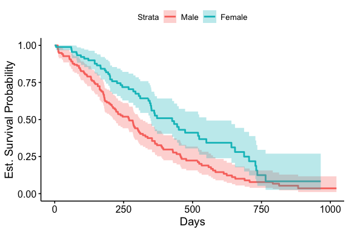

```r
library(survminer)
ggsurvplot(survfit(SurvObj ~ Sex, data = lung2),
     xlab = "Days", ylab = "Est. Survival Probability",
     ylim = c(0, 1),
     conf.int = T, censor = F,
     legend.labs = c("Male", "Female"))
```

## Lung Cancer Data: Probabilities of Death

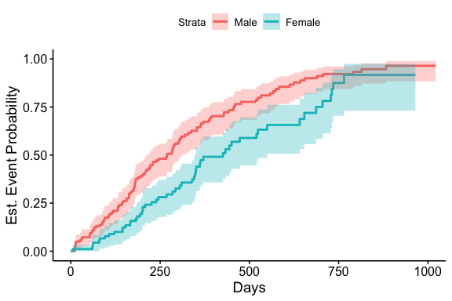

```r
ggsurvplot(survfit(SurvObj ~ Sex, data = lung2),
     xlab = "Days", ylab = "Est. Event Probability",
     ylim = c(0, 1),
     conf.int = T, censor = F, fun = "event",
     legend.labs = c("Male", "Female"))
```

## Proportional Hazards Model

$$\begin{align*}
\lambda(t) &= \lambda_0(t)\exp\left(\beta_1x_1 + \beta_2x_2 + \cdots
+ \beta_px_p \right)
\end{align*}$$

where the **baseline hazard** is assumed to have some distribution (or maybe not!…more on that in just a bit).

Covariates in a PH model have a multiplicative effect on *hazards*. For instance, if $\beta_k = 0.4$, then $\exp(\beta_k) \approx 1.5$. Holding all else equal, an individual with covariate $x_k$ one unit greater than another is expected to have approximately 1.5 times the *hazard* of the event than the other.

Would you rather have a higher linear predictor or a lower linear predictor in a PH model? How does this compare to the AFT model?

## Proportional hazards

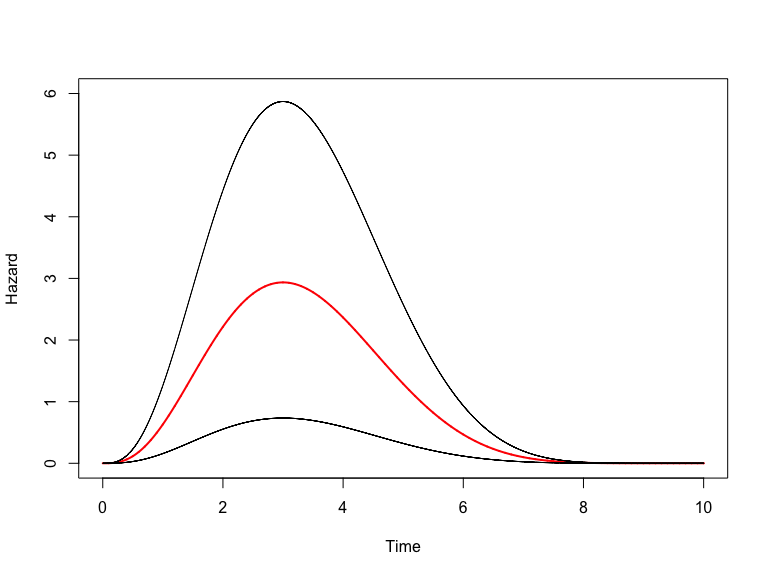

## The Cox proportional hazards model

$$\begin{align*}
\lambda(t) &= \lambda_0(t)\exp\left(\beta_1x_1 + \beta_2x_2 + \cdots
+ \beta_px_p \right)
\end{align*}$$

In a parametric survival model (such as ones we’ve seen), the survival times are assumed to follow a specific distribution, which is a fairly strong assumption.

Often we only care about the $\beta$ terms and not so much the $\lambda_0$. Using the concept of partial likelihood, Cox (1972) found that we can separate inference for the $\beta$ terms from $\lambda_0$.

The Cox model is a **semiparametric** survival model; $\lambda_0(t)$ is left completely unspecified, with no assumptions made on its shape. (A semi-parametric version of the AFT model also exists, but it isn’t popular).

## The Cox proportional hazards model

- By far the most commonly used regression model for survival data
- Attractive interpretations using hazard ratios
- Can be extended to accommodate time-varying covariates, recurrent events, etc.
- Fewer assumptions than fully parametric models, but still requires PH assumption
- Can compare nested models by using partial likelihood ratio statistic, which has asymptotic $\chi^2$ distribution (df = difference in number of parameters)

## Fitting the Cox PH model

```r
cox.fit <- coxph(SurvObj ~ Sex,
                    data = lung2)
summary(cox.fit)
```

```
## Call:
## coxph(formula = SurvObj ~ Sex, data = lung2)
##
##   n= 228, number of events= 165
##
##              coef exp(coef) se(coef)      z Pr(>|z|)
## SexFemale -0.5310    0.5880   0.1672 -3.176  0.00149 **
## ---
## Signif. codes:  0 '***' 0.001 '**' 0.01 '*' 0.05 '.' 0.1 ' ' 1
##
##           exp(coef) exp(-coef) lower .95 upper .95
## SexFemale     0.588      1.701    0.4237     0.816
##
## Concordance= 0.579  (se = 0.021 )
## Likelihood ratio test= 10.63  on 1 df,   p=0.001
## Wald test            = 10.09  on 1 df,   p=0.001
## Score (logrank) test = 10.33  on 1 df,   p=0.001
```

How might we interpret this coefficient? How does it compare to those from our previous models?

## Checking proportional hazards assumption

One way to check the proportional hazards assumption is to plot **log-log survival curves**. The log-log survival curve is a transformation of the estimated Kaplan-Meier survival curve by taking the natural log of an estimated survival probability twice. If the proportional hazards assumption is satisfied, we expect to have roughly parallel lines.

## Checking PH for Sex

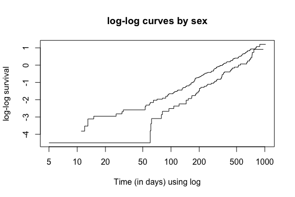

```r
km_sex <- survfit(SurvObj ~ Sex, data = lung2)

plot(km_sex, fun = "cloglog", xlab = "Time (in days) using log",
     ylab = "log-log survival", main = "log-log curves by sex")
```

## Additional Covariates

In either the proportional hazards or accelerated failure time framework, it is straightforward to incorporate additional covariates. Interpretations are similar to those in other regression models with multiple predictors. We will add the continuous Karnovsky performance score, rated by the patient on a scale of 0 (worst) to 100 (best), to the model.

## Additional Covariates

```r
cox.kar.fit <- coxph(SurvObj ~ Sex+pat.karno,
                    data = lung2)
summary(cox.kar.fit)
```

```
## Call:
## coxph(formula = SurvObj ~ Sex + pat.karno, data = lung2)
##
##   n= 225, number of events= 162
##    (3 observations deleted due to missingness)
##
##                coef exp(coef)  se(coef)      z Pr(>|z|)
## SexFemale -0.526176  0.590860  0.168830 -3.117 0.001830 **
## pat.karno -0.020150  0.980051  0.005613 -3.590 0.000331 ***
## ---
## Signif. codes:  0 '***' 0.001 '**' 0.01 '*' 0.05 '.' 0.1 ' ' 1
##
##           exp(coef) exp(-coef) lower .95 upper .95
## SexFemale    0.5909      1.692    0.4244    0.8226
## pat.karno    0.9801      1.020    0.9693    0.9909
##
## Concordance= 0.636  (se = 0.024 )
## Likelihood ratio test= 22.71  on 2 df,   p=1e-05
## Wald test            = 22.22  on 2 df,   p=1e-05
## Score (logrank) test = 22.66  on 2 df,   p=1e-05
```

How do you interpret the results?

## Diagnostics

To assess PH assumption, we can also examine **Schoenfeld residuals**. Intuitively, each Schoenfeld residual is the difference between the observed covariate and the expected covariate for each observed failure, conditioned on the risk set at that time.

In plotting Schoenfeld residuals vs. survival times, we expect to see them randomly distributed around 0.

## Schoenfeld residuals

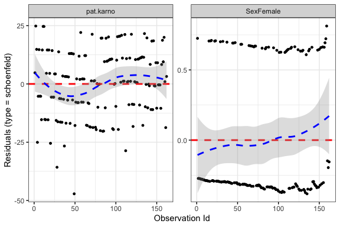

```r
library(survminer)
ggcoxdiagnostics(cox.kar.fit, type = "schoenfeld")
```

## Schoenfeld residuals

What causes the banding in the plots?

```r
table(lung2$Sex)
```

```
##
##   Male Female
##    138     90
```

```r
table(lung2$pat.karno)
```

```
##
##  30  40  50  60  70  80  90 100
##   2   2   4  30  41  51  60  35
```

## Deviance residuals

**Martingale residuals** are based on the difference between observed number of events up until time $Y_i$ and the expected count based on the fitted model.

**Deviance residuals** are a normalized transformation of the martingale residuals that correct their skewness. They should be randomly distributed around mean 0 with a variance of 1.

In practice, these residuals are useful for finding potential outliers: negative values “lived longer than expected” and positive values “died too soon.”

## Deviance residual plot

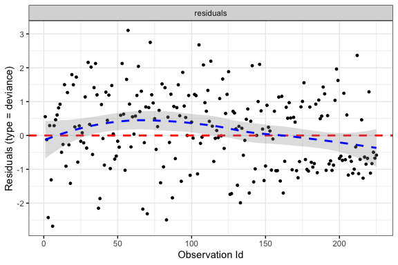

```r
ggcoxdiagnostics(cox.kar.fit, type = "deviance", linear.predictions = F)
```